# Portfolio Assignment 1, Methods 3, 2021, autumn semester

### Exercise 2, part 2 and 3 – (LR)

2. Why is our single-level model bad?
   1. create a new data frame that has three variables, *subject*, *gender* and *f0mn*, where *f0mn* is the average of all responses of each subject, i.e. averaging across *attitude* and_scenario_
   2. build a single-level model that models *f0mn* as dependent on *gender* using this new dataset
   3. make Quantile-Quantile plots, comparing theoretical quantiles to the sample quantiles) using `qqnorm` and `qqline` for the new single-level model and compare it to the old single-level model (from 1).i). Which model’s residuals ($\epsilon$) fulfil the assumptions of the General Linear Model better?)
   4. Also make a quantile-quantile plot for the residuals of the multilevel model with two intercepts. Does it look alright?
3. Plotting the two-intercepts model
   1. Create a plot for each subject, (similar to part 3 in Exercise 1), this time also indicating the fitted value for each of the subjects for each for the scenarios (hint use `fixef` to get the “grand effects” for each gender and `ranef` to get the subject- and scenario-specific effects)

```r
# scenario x f0mn y, attitude = color
ff <- fixef(m6)
ff
```

```
## (Intercept)     genderM
##    246.7650   -115.1746
```

```r
rf <- ranef(m6)
rf <- as.data.frame(rf)
rf
```

```
##      grpvar        term grp    condval   condsd
## 1   subject (Intercept)  F1 -10.490356 8.280794
## 2   subject (Intercept)  F2  10.251809 8.280794
## 3   subject (Intercept)  F3   3.795129 8.280794
## 4   subject (Intercept)  F4 -29.495270 9.095403
## 5   subject (Intercept)  F5  47.093999 8.280794
## 6   subject (Intercept)  F6 -18.396273 8.794359
## 7   subject (Intercept)  F7  -6.976691 8.280794
## 8   subject (Intercept)  F8  -8.521934 8.280794
## 9   subject (Intercept)  F9  12.739587 8.280794
## 10  subject (Intercept)  M1  21.052117 8.280794
## 11  subject (Intercept)  M2  -5.462358 9.453009
## 12  subject (Intercept)  M3  33.561535 8.280794
## 13  subject (Intercept)  M4  16.093337 8.524543
## 14  subject (Intercept)  M5 -28.267430 8.280794
## 15  subject (Intercept)  M6 -12.640202 8.794541
## 16  subject (Intercept)  M7 -24.336998 8.280794
## 17 scenario (Intercept)   1 -11.595496 5.488728
## 18 scenario (Intercept)   2   5.321218 5.532205
## 19 scenario (Intercept)   3   6.795658 5.586194
## 20 scenario (Intercept)   4  11.348815 5.578013
## 21 scenario (Intercept)   5   1.411037 5.488705
## 22 scenario (Intercept)   6  -8.622136 5.489258
## 23 scenario (Intercept)   7  -4.659096 5.488058
```

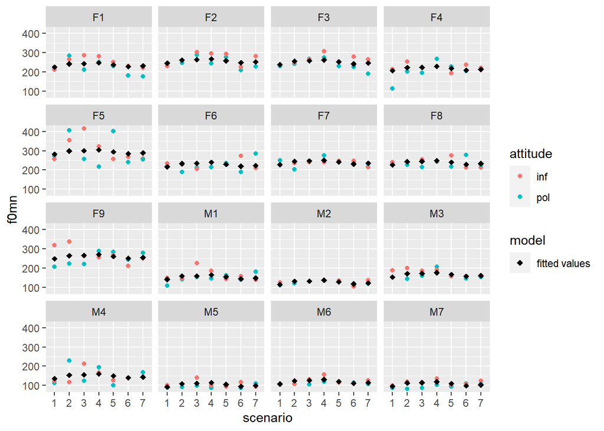

```r
politeness$effect_gender <- 0.0
politeness[politeness$gender == "F", ]$effect_gender <- ff[1]
politeness[politeness$gender == "M", ]$effect_gender <- ff[1] + ff[2]
politeness$intercept_subject <- left_join(politeness, rf, by = c("subject" = "grp"), copy = TRUE, keep = FALSE)$condval
politeness$intercept_scenario <- left_join(politeness, rf, by = c("scenario" = "grp"), copy = TRUE, keep = FALSE)$condval
politeness$predicted <- politeness$effect_gender + politeness$intercept_subject + politeness$intercept_scenario
politeness %>% ggplot(aes(scenario, f0mn, color = attitude)) +
    geom_point() +
    geom_point(aes(y = predicted, shape = "fitted values"), color = "black", size = 2) +
    scale_shape_manual(name = "model", values = c(18)) +
    facet_wrap(vars(subject))
```

```r
deviance(m3)
```

```
## [1] 327033.6
```

```r
deviance(m4, REML = FALSE)
```

```
## [1] 2154.33
```

```r
deviance(m5, REML = FALSE)
```

```
## [1] 2104.175
```

```r
deviance(m6, REML = FALSE)
```

```
## [1] 2095.279
```

```r
politeness_aggregated <- politeness[!is.na(politeness$f0mn), ] %>% group_by(subject) %>% summarize(subject = subject[1], gender = gender[1], f0mn = mean(f0mn))
politeness_aggregated
```

```
## # A tibble: 16 x 3
##    subject gender  f0mn
##    <chr>   <fct>  <dbl>
##  1 F1      F       235.
##  2 F2      F       258.
##  3 F3      F       251.
##  4 F4      F       212.
##  5 F5      F       299.
##  6 F6      F       225.
##  7 F7      F       239.
##  8 F8      F       237.
##  9 F9      F       261.
## 10 M1      M       155.
## 11 M2      M       122.
## 12 M3      M       169.
## 13 M4      M       150.
## 14 M5      M       100.
## 15 M6      M       118.
## 16 M7      M       104.
```

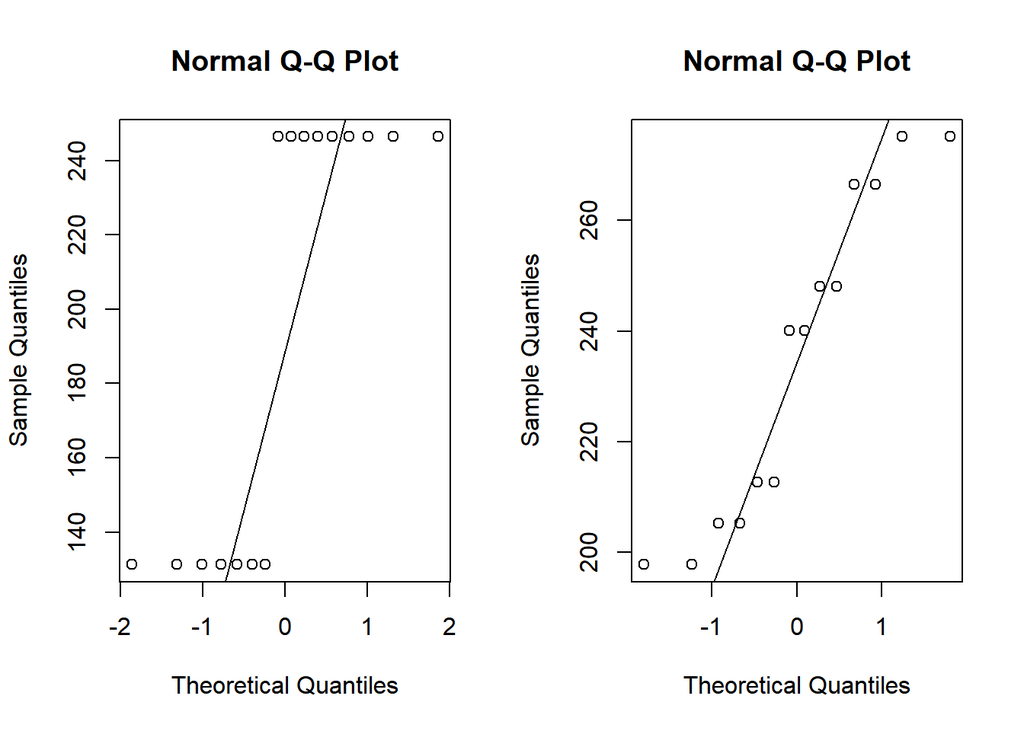

```r
m7 <- lm(f0mn ~ gender, data = politeness_aggregated)
par(mfrow=c(1,2))
qqnorm(fitted.values(m7))
qqline(fitted.values(m7))
qqnorm(fitted.values(m2))
qqline(fitted.values(m2))
```

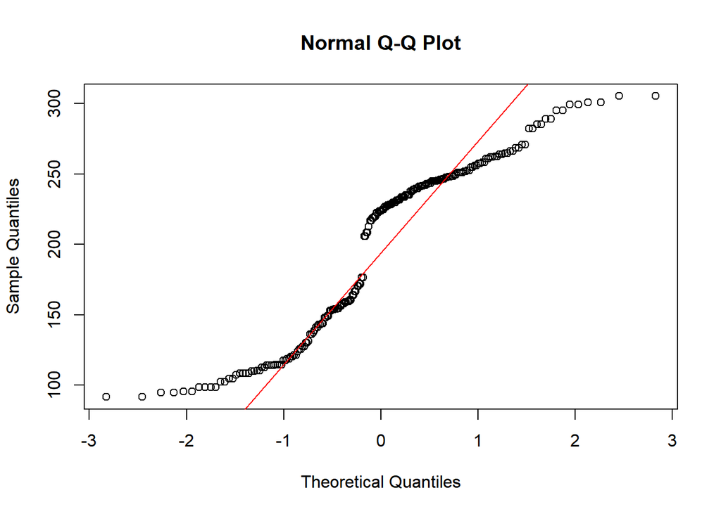

```r
par(mfrow=c(1,1))
qqnorm(fitted.values(m6))
qqline(fitted.values(m6), col = "red")
```

Looking at the plot for the observed and the fitted values it looks as if the model m6 performs reasonably as well.

## Exercise 3 - now with attitude

### Exercise 3, part 1 –(VK)

1. Carry on with the model with the two unique intercepts fitted (*scenario* and *subject*) but now build a new model that has *attitude* as a main effect besides *gender*. After create a separate model that besides the main effects of *attitude* and *gender* also include their interaction

```r
#making a model with two unicue intercepts and having attitude and gender as main effects
m8 <- lmer(formula = f0mn ~ gender + attitude + (1 | subject) + (1 | scenario), data = politeness)
summary(m8)
```

```
## Linear mixed model fit by REML ['lmerMod']
## Formula: f0mn ~ gender + attitude + (1 | subject) + (1 | scenario)
##    Data: politeness
##
## REML criterion at convergence: 2065.1
##
## Scaled residuals:
##     Min      1Q  Median      3Q     Max
## -2.8511 -0.6081 -0.0602  0.4329  3.8745
##
## Random effects:
##  Groups   Name        Variance Std.Dev.
##  subject  (Intercept) 585.6    24.20
##  scenario (Intercept) 106.7    10.33
##  Residual             882.7    29.71
## Number of obs: 212, groups:  subject, 16; scenario, 7
##
## Fixed effects:
##             Estimate Std. Error t value
## (Intercept)  254.398      9.597  26.507
## genderM     -115.437     12.881  -8.962
## attitudepol  -14.819      4.096  -3.618
##
## Correlation of Fixed Effects:
##             (Intr) gendrM
## genderM     -0.587
## attitudepol -0.220  0.006
```

```r
fitted.values(m8)
```

[output not shown]

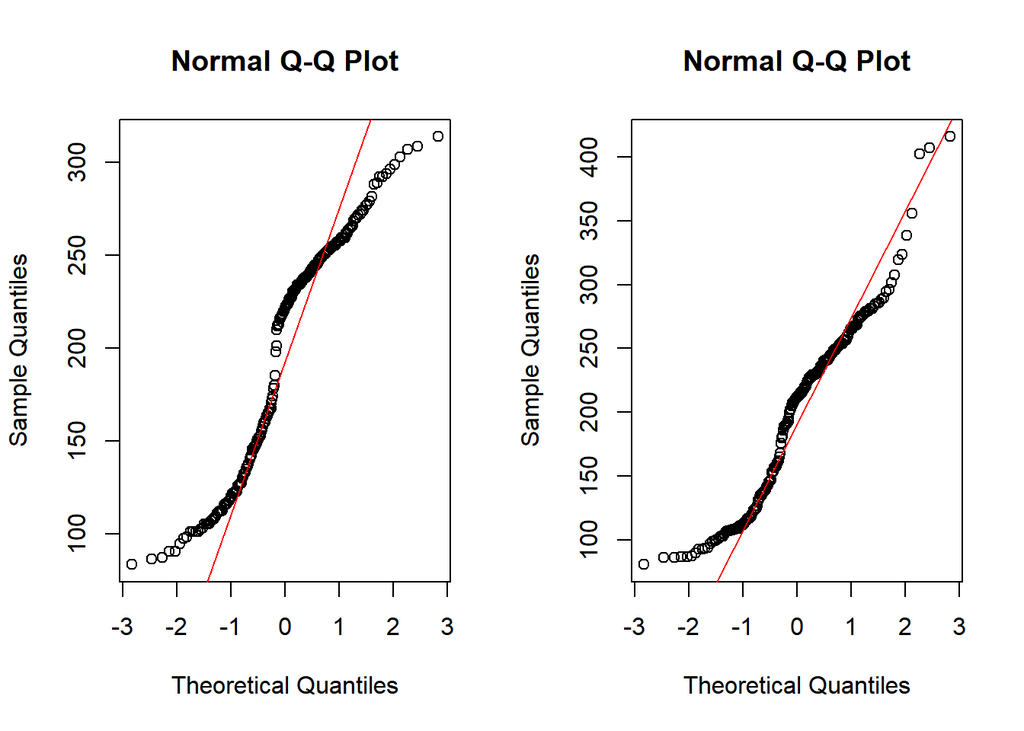

```r
par(mfrow=c(1,2))
qqnorm(fitted.values(m8))
qqline(fitted.values(m8), col = "red")
qqnorm(politeness$f0mn)
qqline(politeness$f0mn, col = "red")
```

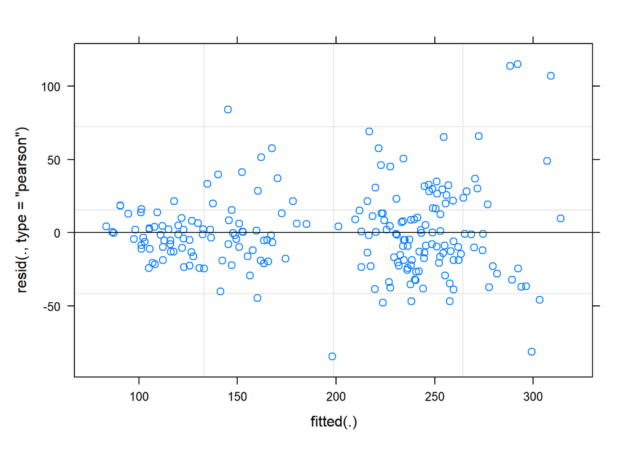

```r
plot(m8)
```

```r
#a model that additionally includes the interaction between the main effects (attitude and gender)
m9 <- lmer(formula = f0mn ~ gender + attitude + gender:attitude + (1 | subject) + (1 | scenario), data = politeness)
summary(m9)
```

```
## Linear mixed model fit by REML ['lmerMod']
## Formula: f0mn ~ gender + attitude + gender:attitude + (1 | subject) +
##     (1 | scenario)
##    Data: politeness
##
## REML criterion at convergence: 2058.6
##
## Scaled residuals:
##     Min      1Q  Median      3Q     Max
## -2.8120 -0.5884 -0.0645  0.4014  3.9100
##
## Random effects:
##  Groups   Name        Variance Std.Dev.
##  subject  (Intercept) 584.4    24.17
##  scenario (Intercept) 106.4    10.32
##  Residual             885.5    29.76
## Number of obs: 212, groups:  subject, 16; scenario, 7
##
## Fixed effects:
##                     Estimate Std. Error t value
## (Intercept)          255.618      9.761  26.186
## genderM             -118.232     13.531  -8.738
## attitudepol          -17.192      5.423  -3.170
## genderM:attitudepol    5.544      8.284   0.669
##
## Correlation of Fixed Effects:
##             (Intr) gendrM atttdp
## genderM     -0.606
## attitudepol -0.286  0.206
## gndrM:tttdp  0.187 -0.309 -0.654
```

The model m9 can be read as following: The intercept for women/inf are $\approx 256 Hz$, when we look at men with the same attitude their pitch drops by $\approx 118 Hz$. Overall a polite attitude will result in a drop in pitch by $\approx 17 Hz$, however for men it will only be $-17.2+5.5 \approx 11.6 Hz$. Korean women’s relative drop in pitch is therefore larger than male’s in a polite situation according to this sample.

### Exercise 3, part 2 –(KV)

2. Compare the three models (1. gender as a main effect; 2. gender and attitude as main effects; 3. gender and attitude as main effects and the interaction between them.

```r
#comparing the models
anova(m6, m8, m9)
```

```
## refitting model(s) with ML (instead of REML)
```

```
## Data: politeness
## Models:
## m6: f0mn ~ gender + (1 | subject) + (1 | scenario)
## m8: f0mn ~ gender + attitude + (1 | subject) + (1 | scenario)
## m9: f0mn ~ gender + attitude + gender:attitude + (1 | subject) + (1 | scenario)
##    npar    AIC    BIC  logLik deviance   Chisq Df Pr(>Chisq)
## m6    5 2105.2 2122.0 -1047.6   2095.2
## m8    6 2094.5 2114.6 -1041.2   2082.5 12.6868  1  0.0003683 ***
## m9    7 2096.0 2119.5 -1041.0   2082.0  0.4551  1  0.4998998
## ---
## Signif. codes:  0 '***' 0.001 '**' 0.01 '*' 0.05 '.' 0.1 ' ' 1
```

```r
piecewiseSEM::rsquared(c(m6, m8, m9))
```

```
##   Response   family     link method  Marginal Conditional
## 1     f0mn gaussian identity   none 0.6677206   0.8077964
## 2     f0mn gaussian identity   none 0.6782542   0.8196777
## 3     f0mn gaussian identity   none 0.6782490   0.8192531
```

### Exercise 3, part 3 –(KV)

3. Choose the model that you think describe the data the best - and write a short report on the main findings based on this model.

```r
summary(m8)
```

```
## Linear mixed model fit by REML ['lmerMod']
## Formula: f0mn ~ gender + attitude + (1 | subject) + (1 | scenario)
##    Data: politeness
##
## REML criterion at convergence: 2065.1
##
## Scaled residuals:
##     Min      1Q  Median      3Q     Max
## -2.8511 -0.6081 -0.0602  0.4329  3.8745
##
## Random effects:
##  Groups   Name        Variance Std.Dev.
##  subject  (Intercept) 585.6    24.20
##  scenario (Intercept) 106.7    10.33
##  Residual             882.7    29.71
## Number of obs: 212, groups:  subject, 16; scenario, 7
##
## Fixed effects:
##             Estimate Std. Error t value
## (Intercept)  254.398      9.597  26.507
## genderM     -115.437     12.881  -8.962
## attitudepol  -14.819      4.096  -3.618
##
## Correlation of Fixed Effects:
##             (Intr) gendrM
## genderM     -0.587
## attitudepol -0.220  0.006
```

This dataset consists of the basic demographic information of 16 Korean participants, and their observed pitch in different situations that require either an informal or polite(formal) attitude.

The model we chose as the best is m8. Consistent with the conclusions of the original oauthor’s study, this model showed that women on average have a higher pitch than men BUT it also suggested a negative relationship between *attitude* and pitch with p-values<0.001. It would seem that both Korean men’s and women’s frequency of voice drops when having a polite attitude.

Subjects and scenarios should have different intercepts because it would be assumed they would all have different baselines, (and therefore need different intercepts to account for this). Different subjects will naturally already speak at a different pitch level, so separate intercepts allows us to account for these differences. The different scenarios may also need separate intercepts as certain scenarios may result in participants lowering or raising their pitch to meet the appropriate ambiance of the scenario. Once again, by including separate intercepts for scenarios then we should be accounting for these differences in our models.

Furthermore the output of the summary function shows that more variance is explained by the random effect of the subject than that of the scenario, further strengthening the choice of multilevel modelling.

And here’s a QQ-plot of our chosen model

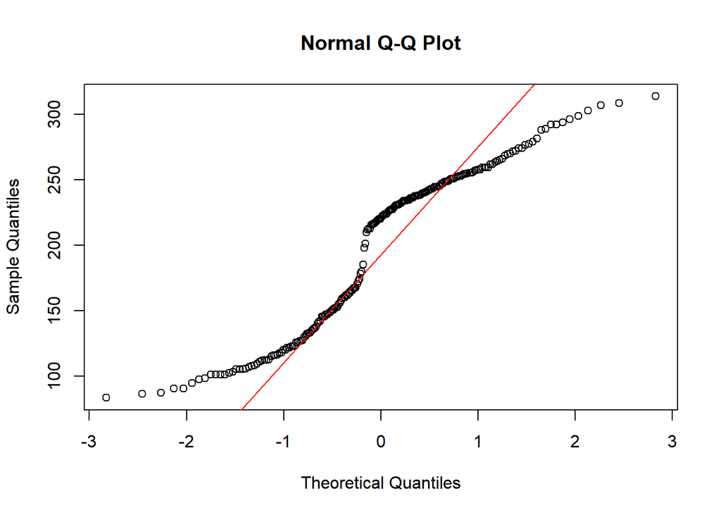

```r
qqnorm(fitted.values(m8))
qqline(fitted.values(m8), col = "red")
```